# DIANA_MARIA_ARANGO_BOTERO_-_ANDRÉS_JULIAN_CARO_RESTREPO

2023-07-30

# Bloque 0

## Problema 1

```r
x <- 256
```

```r
print(x)
```

```
## [1] 256
```

```r
y <- 559;y
```

```
## [1] 559
```

```r
secuencia <- seq(20, 35)
print(secuencia)
```

```
##  [1] 20 21 22 23 24 25 26 27 28 29 30 31 32 33 34 35
```

```r
secuencia_1 <- seq(122, 137)
print(secuencia_1)
```

```
##  [1] 122 123 124 125 126 127 128 129 130 131 132 133 134 135 136 137
```

```r
secuencia_2 <- 122:137
print(secuencia_2)
```

```
##  [1] 122 123 124 125 126 127 128 129 130 131 132 133 134 135 136 137
```

```r
secuencia_1 <- seq(122, 137, 3)
secuencia_3 <- secuencia_1
print(secuencia_3)
```

```
## [1] 122 125 128 131 134 137
```

```r
#secuencia_1 <- 122:137,by=3
secuencia_3 <- secuencia_1
print(secuencia_3)
```

```
## [1] 122 125 128 131 134 137
```

## Problema 2

```r
vector_1 <- matrix(122:137, 2, 2)
print(vector_1)
```

```
##      [,1] [,2]
## [1,]  122  124
## [2,]  123  125
```

```r
matriz_1 <- matrix(122:137, nrow = 4)
```

```r
z <- 0:10
vector_2 <- z^3
print(vector_2)
```

```
##  [1]    0    1    8   27   64  125  216  343  512  729 1000
```

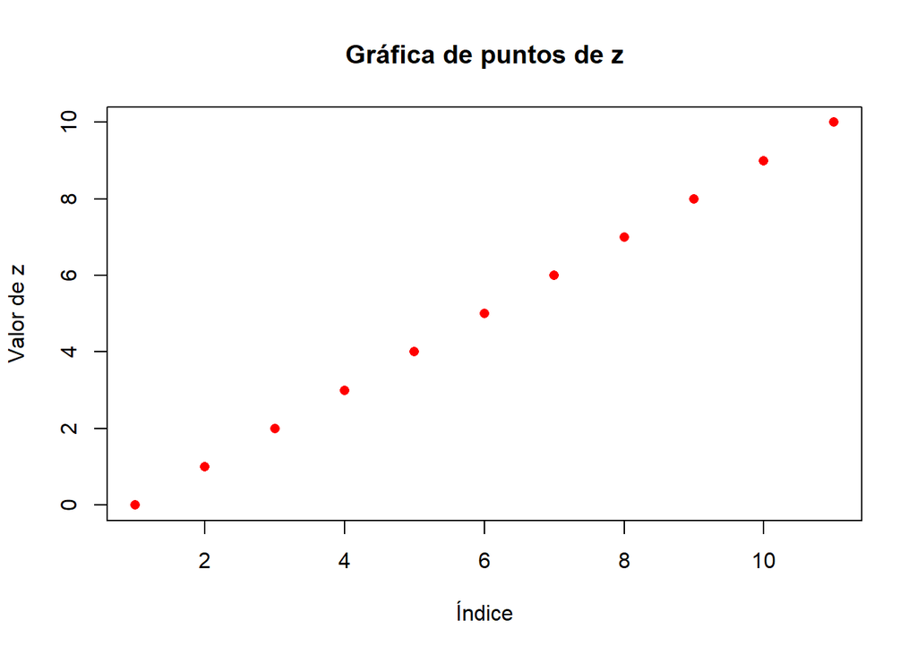

```r
plot(z, pch = 16, col = "red", main = "Gráfica de puntos de z", xlab = "Índice", ylab = "Valor de z")
```

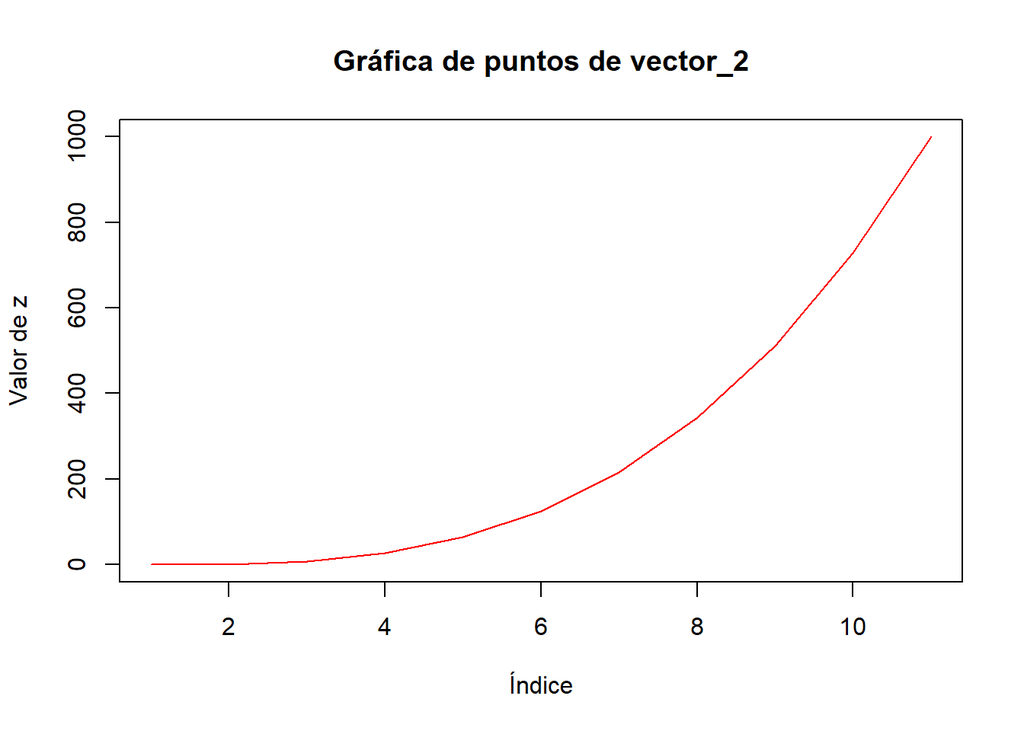

```r
vector_2 <- z^3
plot(vector_2, type = "l", col = "red", main = "Gráfica de puntos de vector_2", xlab = "Índice", ylab = "Valor de z")
```

```r
matriz_1[3,2] <- 135
print(matriz_1)
```

```
##      [,1] [,2] [,3] [,4]
## [1,]  122  126  130  134
## [2,]  123  127  131  135
## [3,]  124  135  132  136
## [4,]  125  129  133  137
```

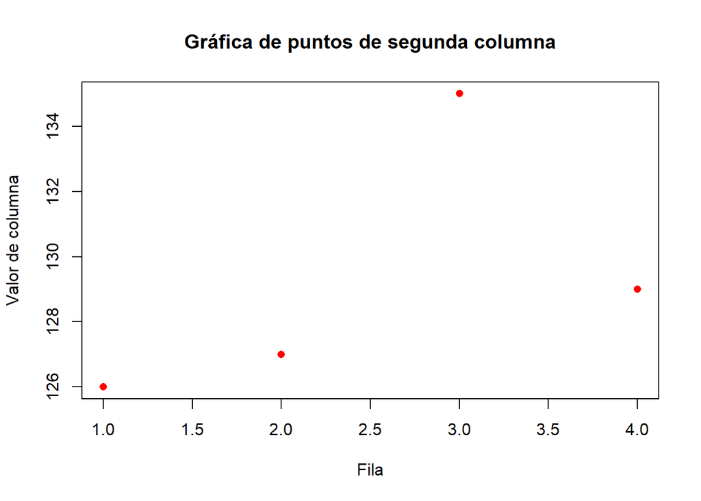

```r
plot(matriz_1[,2], pch = 16, col = "red", main = "Gráfica de puntos de segunda columna", xlab = "Fila", ylab = "Valor de columna")
```

# Bloque 1

## Problema 3

```r
#install.packages("readxl")
library(readxl)
Info_clientes_banco <- read_excel("C:/Users/Julianskiy/Downloads/Info_clientes_banco.xlsx")
```

## Problema 4

**ID_cliente:** Cualitativa y nominal

**Asesor:** Cualitativa y nominal

**Sucursal:** Cualitativa y nominal

**Segmento:** Cualitativa y ordinal

**Tipo_cliente:** Cualitativa y nominal

**Cuenta_corriente:** Cualitativa y nominal

**Saldo_cuenta_corriente:** Cuantitativa y continua

**Cuenta_ahorros:** Cualitativa y nominal

**Saldo_cuenta_ahorros:** Cuantitativa y continua

**Credito_vivienda:** Cualitativa y nominal

**Saldo_credito_vivienda:** Cuantitativa y continua

**Vehiculo_1:** Cualitativa y nominal

**Valor_vehiculo_1:** Cuantitativa y discreta

**Vehiculo_2:** Cualitativa y nominal

**Valor_vehiculo_2:** Cuantitativa y discreta

**Inmueble_1:** Cualitativa y nominal

**Valor_inmueble_1:** Cuantitativa y discreta

**Inmueble_2:** Cualitativa y nominal

**Valor_inmueble_2:** Cuantitativa y discreta

## Problema 5

```r
# DATOS

asesores <- table(Info_clientes_banco$Asesor)
totalAsesores <- sum(asesores)
relativaAsesores <- asesores / totalAsesores

sucursal <- table(Info_clientes_banco$Sucursal)
totalSucursal <- sum(sucursal)
relativaSucursal <- sucursal / totalSucursal

segmento <- table(Info_clientes_banco$Segmento)
totalSegmento <- sum(segmento)
relativaSegmento <- segmento / totalSegmento

tipo_cliente <- table(Info_clientes_banco$Tipo_Cliente)
totalTipoCliente <- sum(tipo_cliente)
relativaTipoCliente <- tipo_cliente / totalTipoCliente

# TABLAS
print("-------------------------ASESORES------------------------")
```

```
## [1] "-------------------------ASESORES------------------------"
```

```r
tablaAsesores <- cbind(asesores, relativaAsesores)
colnames(tablaAsesores) <- c("Frecuencia Absoluta", "Frecuencia Relativa")
print(tablaAsesores)
```

```
##           Frecuencia Absoluta Frecuencia Relativa
## JDALVAREZ                 417           0.2087087
## LVELEZ                    406           0.2032032
## MGOMEZ                    380           0.1901902
## NBERRIO                   378           0.1891892
## TPEREZ                    417           0.2087087
```

```r
print("-------------------------SUCURSAL------------------------")
```

```
## [1] "-------------------------SUCURSAL------------------------"
```

```r
tablaSucursal <- cbind(sucursal, relativaSucursal)
colnames(tablaSucursal) <- c("Frecuencia Absoluta", "Frecuencia Relativa")
print(tablaSucursal)
```

```
##          Frecuencia Absoluta Frecuencia Relativa
## AMERICAS                 467           0.2337337
## CENTRO                   475           0.2377377
## PRADO                    546           0.2732733
## VILLA                    510           0.2552553
```

```r
print("-------------------------SEGMENTO------------------------")
```

```
## [1] "-------------------------SEGMENTO------------------------"
```

```r
tablaSegmento <- cbind(segmento, relativaSegmento)
colnames(tablaSegmento) <- c("Frecuencia Absoluta", "Frecuencia Relativa")
print(tablaSegmento)
```

```
##             Frecuencia Absoluta Frecuencia Relativa
## ALTO                        196          0.09809810
## ALTO-PLUS                   209          0.10460460
## BASICO                      596          0.29829830
## BASICO-PLUS                 397          0.19869870
## MEDIO                       189          0.09459459
## MEDIO-PLUS                  202          0.10110110
## PREMIUM                     209          0.10460460
```

```r
print("-------------------------TIPO_CLIENTE------------------------")
```

```
## [1] "-------------------------TIPO_CLIENTE------------------------"
```

```r
tablaTipoCliente <- cbind(tipo_cliente, relativaTipoCliente)
colnames(tablaTipoCliente) <- c("Frecuencia Absoluta", "Frecuencia Relativa")
print(tablaTipoCliente)
```

```
##            Frecuencia Absoluta Frecuencia Relativa
## APOSTOL                    209           0.1046046
## DECIDIDO                   214           0.1071071
## INDECISO                   607           0.3038038
## NEGOCIADOR                 196           0.0980981
## REHEN                      772           0.3863864
```

*Gracias a esas tablas podemos concluir lo siguiente:*

- Los asesores con más clientes son Jdalvarez y Tperez.
- La sucursal con más clientes es la de PRADO, de donde provienen 27% de los clientes.
- La mitad de los clientes tienen el plan basico o basico-plus
- El 38% de los clientes son de tipo rehen

## Problema 6

```r
(asesores_cuenta_corriente <- Info_clientes_banco[Info_clientes_banco$Cuenta_corriente == 1, ])
```

```
## # A tibble: 978 × 19
##    ID_cliente Asesor    Sucursal Segmento    Tipo_Cliente Cuenta_corriente
##         <dbl> <chr>     <chr>    <chr>       <chr>                   <dbl>
##  1     982124 MGOMEZ    CENTRO   ALTO        REHEN                       1
##  2     298851 MGOMEZ    CENTRO   BASICO      REHEN                       1
##  3     284788 JDALVAREZ AMERICAS MEDIO       INDECISO                    1
##  4     923909 JDALVAREZ CENTRO   ALTO        APOSTOL                     1
##  5     339200 MGOMEZ    AMERICAS BASICO-PLUS INDECISO                    1
##  6     944866 NBERRIO   VILLA    PREMIUM     REHEN                       1
##  7     903327 JDALVAREZ VILLA    MEDIO-PLUS  APOSTOL                     1
##  8     118864 TPEREZ    PRADO    BASICO      DECIDIDO                    1
##  9     979878 TPEREZ    AMERICAS PREMIUM     INDECISO                    1
## 10     303082 NBERRIO   PRADO    BASICO      INDECISO                    1
## # ℹ 968 more rows
## # ℹ 13 more variables: Saldo_cuenta_corriente <dbl>, Cuenta_ahorros <dbl>,
## #   Saldo_cuenta_ahorros <dbl>, Credito_vivienda <dbl>,
## #   Saldo_credito_vivienda <dbl>, Veh_1 <dbl>, Valor_veh_1 <dbl>, Veh_2 <dbl>,
## #   Valor_veh_2 <dbl>, Inmueble_1 <dbl>, Valor_inmuble_1 <dbl>,
## #   Inmueble_2 <dbl>, Valor_inmuble_2 <dbl>
```

## Problema 7

```r
(vec <- table(asesores_cuenta_corriente$Asesor))
```

```
##
## JDALVAREZ    LVELEZ    MGOMEZ   NBERRIO    TPEREZ
##       195       202       182       197       202
```

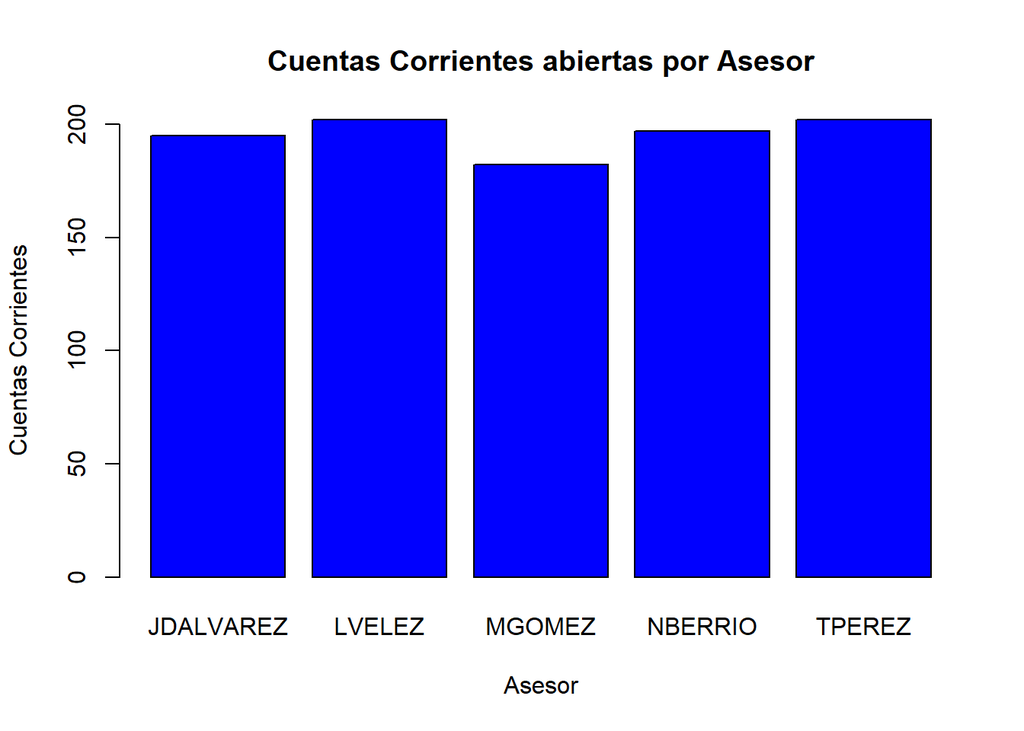

```r
barplot(vec, col = "blue", main = "Cuentas Corrientes abiertas por Asesor", xlab = "Asesor", ylab = "Cuentas Corrientes")
```

* Gracias a la grafica s epuede apreciar que, de hecho, todos los asesores tienen un porcentaje de cliente mas o menos similar

## Problema 8

### Cuentas de Ahorros

```r
(asesores_cuenta_ahorros <- Info_clientes_banco[Info_clientes_banco$Cuenta_ahorros == 1, ])
```

```
## # A tibble: 975 × 19
##    ID_cliente Asesor    Sucursal Segmento    Tipo_Cliente Cuenta_corriente
##         <dbl> <chr>     <chr>    <chr>       <chr>                   <dbl>
##  1     153532 LVELEZ    VILLA    BASICO-PLUS INDECISO                    0
##  2     298851 MGOMEZ    CENTRO   BASICO      REHEN                       1
##  3     284788 JDALVAREZ AMERICAS MEDIO       INDECISO                    1
##  4     923909 JDALVAREZ CENTRO   ALTO        APOSTOL                     1
##  5     600050 TPEREZ    AMERICAS PREMIUM     REHEN                       0
##  6     944866 NBERRIO   VILLA    PREMIUM     REHEN                       1
##  7     903327 JDALVAREZ VILLA    MEDIO-PLUS  APOSTOL                     1
##  8     440017 MGOMEZ    VILLA    BASICO-PLUS INDECISO                    0
##  9     979878 TPEREZ    AMERICAS PREMIUM     INDECISO                    1
## 10     303082 NBERRIO   PRADO    BASICO      INDECISO                    1
## # ℹ 965 more rows
## # ℹ 13 more variables: Saldo_cuenta_corriente <dbl>, Cuenta_ahorros <dbl>,
## #   Saldo_cuenta_ahorros <dbl>, Credito_vivienda <dbl>,
## #   Saldo_credito_vivienda <dbl>, Veh_1 <dbl>, Valor_veh_1 <dbl>, Veh_2 <dbl>,
## #   Valor_veh_2 <dbl>, Inmueble_1 <dbl>, Valor_inmuble_1 <dbl>,
## #   Inmueble_2 <dbl>, Valor_inmuble_2 <dbl>
```

```r
(vec2 <- table(asesores_cuenta_ahorros$Asesor))
```

```
##
## JDALVAREZ    LVELEZ    MGOMEZ   NBERRIO    TPEREZ
##       212       195       174       185       209
```

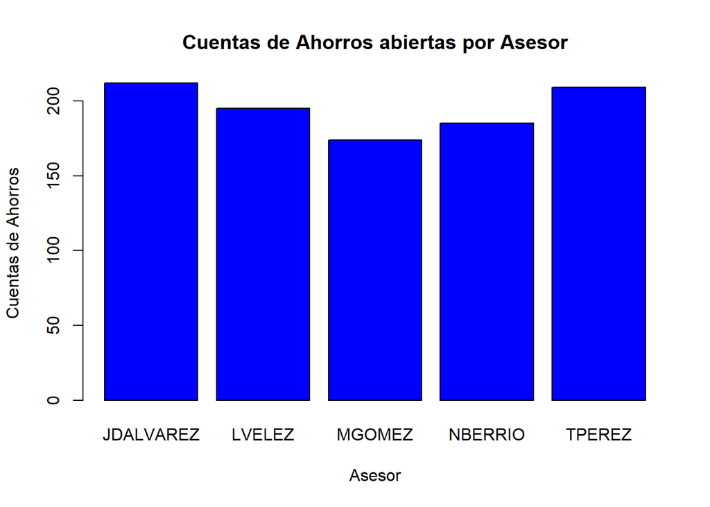

```r
barplot(vec2, col = "blue", main = "Cuentas de Ahorros abiertas por Asesor", xlab = "Asesor", ylab = "Cuentas de Ahorros")
```

* En cuanto a cuentas de ahorros, podemos notar menos uniformidad en los datos.

### Créditos de Davivienda

```r
(asesores_credito <- Info_clientes_banco[Info_clientes_banco$Credito_vivienda == 1, ])
```

```
## # A tibble: 1,040 × 19
##    ID_cliente Asesor    Sucursal Segmento    Tipo_Cliente Cuenta_corriente
##         <dbl> <chr>     <chr>    <chr>       <chr>                   <dbl>
##  1     153532 LVELEZ    VILLA    BASICO-PLUS INDECISO                    0
##  2     771993 MGOMEZ    AMERICAS ALTO-PLUS   APOSTOL                     0
##  3     298851 MGOMEZ    CENTRO   BASICO      REHEN                       1
##  4     284788 JDALVAREZ AMERICAS MEDIO       INDECISO                    1
##  5     923909 JDALVAREZ CENTRO   ALTO        APOSTOL                     1
##  6     424957 JDALVAREZ PRADO    ALTO        REHEN                       0
##  7     118864 TPEREZ    PRADO    BASICO      DECIDIDO                    1
##  8     440017 MGOMEZ    VILLA    BASICO-PLUS INDECISO                    0
##  9     979878 TPEREZ    AMERICAS PREMIUM     INDECISO                    1
## 10     303082 NBERRIO   PRADO    BASICO      INDECISO                    1
## # ℹ 1,030 more rows
## # ℹ 13 more variables: Saldo_cuenta_corriente <dbl>, Cuenta_ahorros <dbl>,
## #   Saldo_cuenta_ahorros <dbl>, Credito_vivienda <dbl>,
## #   Saldo_credito_vivienda <dbl>, Veh_1 <dbl>, Valor_veh_1 <dbl>, Veh_2 <dbl>,
## #   Valor_veh_2 <dbl>, Inmueble_1 <dbl>, Valor_inmuble_1 <dbl>,
## #   Inmueble_2 <dbl>, Valor_inmuble_2 <dbl>
```

```r
(vec3 <- table(asesores_credito$Asesor))
```

```
##
## JDALVAREZ    LVELEZ    MGOMEZ   NBERRIO    TPEREZ
##       205       212       204       196       223
```

[figure not shown]

```r
barplot(vec3, col = "blue", main = "Cuentas de Ahorros abiertas por Asesor", xlab = "Asesor", ylab = "Cuentas de Ahorros")
```

## Problema 9

```r
saldo_cuentas_corrientes <- Info_clientes_banco$Saldo_cuenta_corriente; saldo_cuentas_corrientes
```

[output not shown]

[output cut: 318 more lines]

## Problema 10

```r
#saldoTotal <- sum(saldo);saldoTotal
```

## Problema 11

```r
resultado_suma_Saldo_cuenta_ahorros <- sum(Info_clientes_banco$Saldo_cuenta_ahorros)
resultado_suma_Saldo_cuenta_ahorros
```

```
## [1] 10447964890
```

```r
resultado_suma_Saldo_cuenta_corriente <- sum(Info_clientes_banco$Saldo_cuenta_corriente)
resultado_suma_Saldo_cuenta_corriente
```

```
## [1] 932768208
```

```r
if (resultado_suma_Saldo_cuenta_ahorros > resultado_suma_Saldo_cuenta_corriente) {
  print("El banco tiene mas dinero en las cuentas de ahorros")
} else {
  print("El banco tiene mas dinero en las cuentas corrientes")
}
```

```
## [1] "El banco tiene mas dinero en las cuentas de ahorros"
```

```r
Dinero_total <- resultado_suma_Saldo_cuenta_ahorros + resultado_suma_Saldo_cuenta_corriente
Dinero_total
```

```
## [1] 11380733098
```

```r
porcentaje_ahorros <- (resultado_suma_Saldo_cuenta_ahorros / Dinero_total) * 100

porcentaje_corriente <- (resultado_suma_Saldo_cuenta_corriente / Dinero_total) * 100

print(porcentaje_ahorros)
```

```
## [1] 91.80397
```

```r
print(porcentaje_corriente)
```

```
## [1] 8.196029
```

## Problema 12

## Problema 13

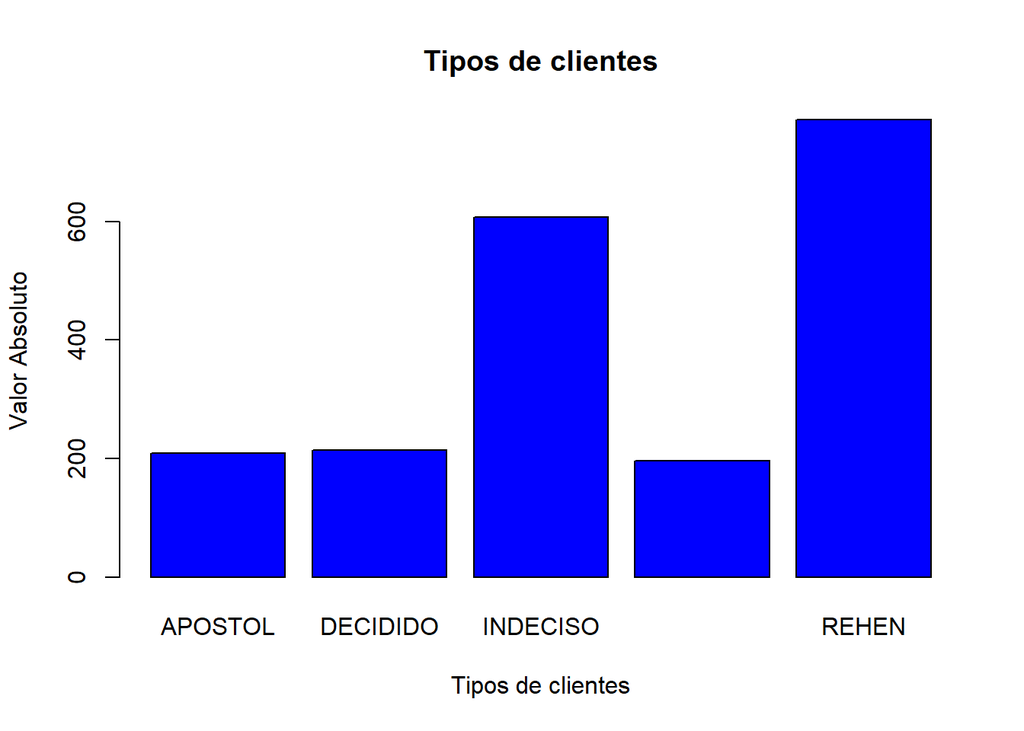

```r
barplot(tipo_cliente, col = "blue", main = "Tipos de clientes", xlab = "Tipos de clientes", ylab = "Valor Absoluto")
```

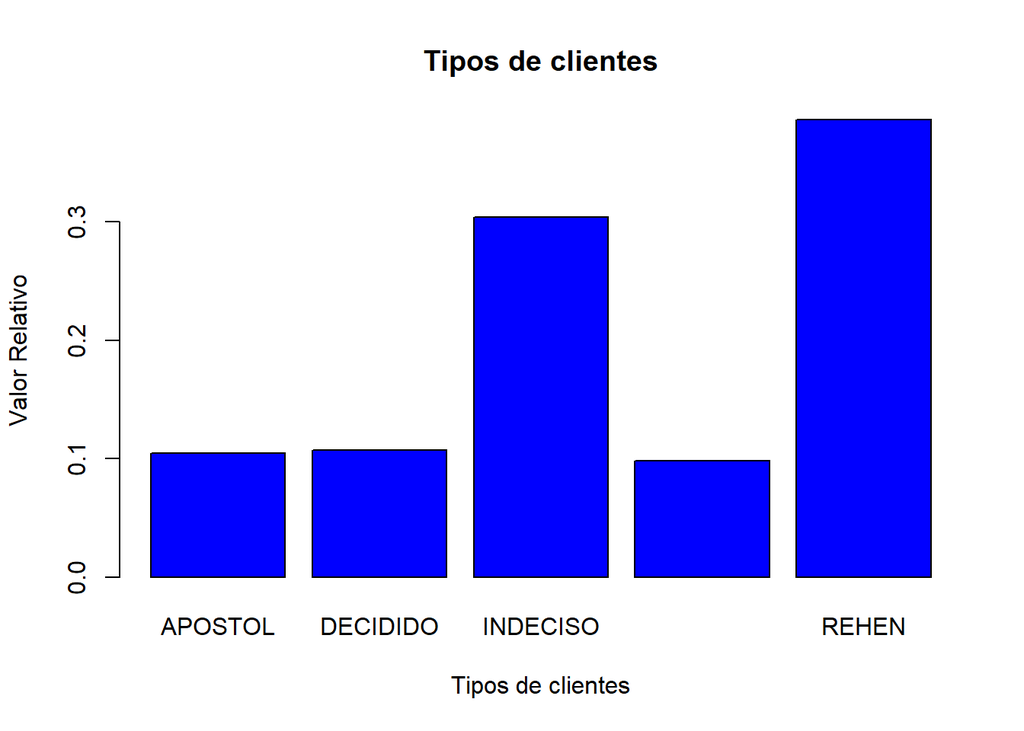

```r
barplot(relativaTipoCliente, col = "blue", main = "Tipos de clientes", xlab = "Tipos de clientes", ylab = "Valor Relativo")
```

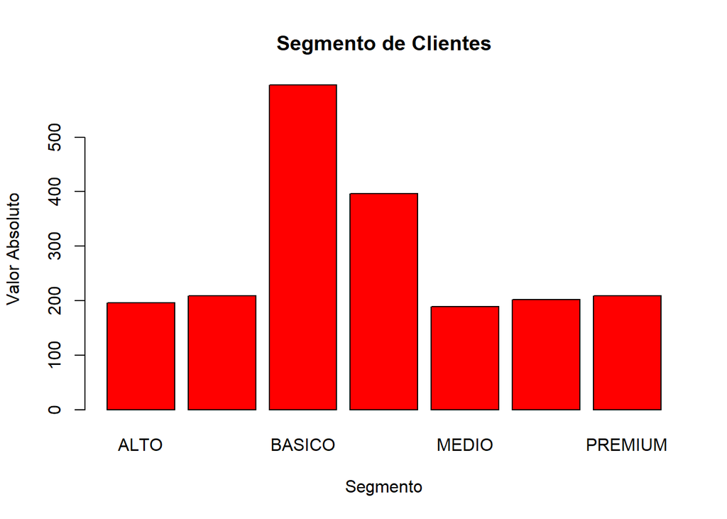

```r
barplot(segmento, col = "red", main = "Segmento de Clientes", xlab = "Segmento", ylab = "Valor Absoluto")
```

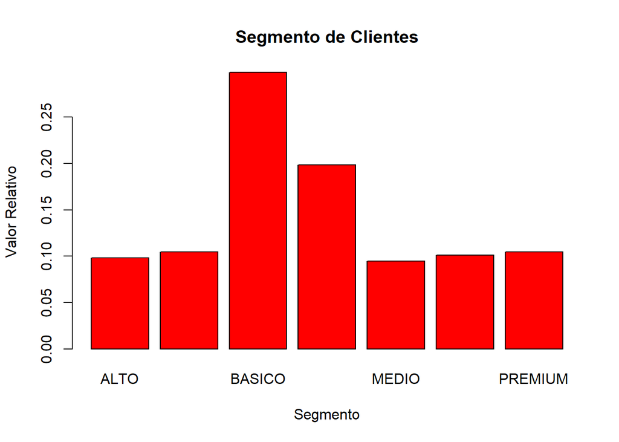

```r
barplot(relativaSegmento, col = "red", main = "Segmento de Clientes", xlab = "Segmento", ylab = "Valor Relativo")
```

# Bloque 2

## Problema 14

```r
Info_clientes_banco$Vehículos <- Info_clientes_banco$Veh_1 + Info_clientes_banco$Veh_2

Info_clientes_banco$Valor_vehículos <- Info_clientes_banco$Valor_veh_1 + Info_clientes_banco$Valor_veh_2

Info_clientes_banco_ampliada <- Info_clientes_banco

head(Info_clientes_banco_ampliada)
```

```
## # A tibble: 6 × 21
##   ID_cliente Asesor    Sucursal Segmento    Tipo_Cliente Cuenta_corriente
##        <dbl> <chr>     <chr>    <chr>       <chr>                   <dbl>
## 1     153532 LVELEZ    VILLA    BASICO-PLUS INDECISO                    0
## 2     771993 MGOMEZ    AMERICAS ALTO-PLUS   APOSTOL                     0
## 3     982124 MGOMEZ    CENTRO   ALTO        REHEN                       1
## 4     298851 MGOMEZ    CENTRO   BASICO      REHEN                       1
## 5     284788 JDALVAREZ AMERICAS MEDIO       INDECISO                    1
## 6     923909 JDALVAREZ CENTRO   ALTO        APOSTOL                     1
## # ℹ 15 more variables: Saldo_cuenta_corriente <dbl>, Cuenta_ahorros <dbl>,
## #   Saldo_cuenta_ahorros <dbl>, Credito_vivienda <dbl>,
## #   Saldo_credito_vivienda <dbl>, Veh_1 <dbl>, Valor_veh_1 <dbl>, Veh_2 <dbl>,
## #   Valor_veh_2 <dbl>, Inmueble_1 <dbl>, Valor_inmuble_1 <dbl>,
## #   Inmueble_2 <dbl>, Valor_inmuble_2 <dbl>, Vehículos <dbl>,
## #   Valor_vehículos <dbl>
```

## Problema 15

```r
(valor_vehiculos <- Info_clientes_banco_ampliada[Info_clientes_banco_ampliada$Vehículos > 0, c(21)])
```

```
## # A tibble: 953 × 1
##    Valor_vehículos
##              <dbl>
##  1        88791668
##  2        19003555
##  3       176909287
##  4       184909907
##  5       196604866
##  6       155171029
##  7       131058706
##  8       387283835
##  9       177576761
## 10        16455763
## # ℹ 943 more rows
```